# BioHackathon 2017

#### Contents:

- Introduction
- Microarray Data Workflow
- RNA-Seq Data Workflow
- Retrieving Metdata
- Workflow Reproduciblity

# Introduction

This script is designed to download and process data from [GEO](https://www.ncbi.nlm.nih.gov/geo/). For each downloaded dataset, the data is processed and converted into an expression matrix (rows are genes and columns are samples). Additionally, using the [GEO Metadata Database](https://www.ncbi.nlm.nih.gov/geo/info/geo_paccess.html) specific features for each dataset are collected and kept for downstream processing. Prior to running differential expression analysis, the expression data is verified to ensure both normalization and log transformation had been performed. The RNA-seq data is put through additional verification to ensure that it has been run through [voom](http://web.mit.edu/~r/current/arch/i386_linux26/lib/R/library/limma/html/voom.html). This additional step permits the same limma pipeline to be used for both processed microarray and RNA-seq data ([Law et al., 2014](https://www.ncbi.nlm.nih.gov/pubmed/24485249), [limma user guide](http://bioconductor.org/packages/release/bioc/vignettes/limma/inst/doc/usersguide.pdf)).

```r
# load needed libraries
library(Biobase)
library(data.table)
library(edgeR)
library(EMA)
library(GEOmetadb)
library(GEOquery)
library(ggplot2)
library(Glimma)
library(gplots)
library(knitr)
library(latex2exp)
library(limma)
library(Mus.musculus)
library(mygene)
library(RColorBrewer)
library(R.utils)
```

## Microarray Data

### Accessing GEO Data

Microarray data is downloaded from GEO as a GEO Series, from which an expression set and gene expression matrix are derived.

```r
# Use the getGEO() function to download the GEO data for the id
gse_data <- GEOquery::getGEO('GSE14722', GSEMatrix=TRUE, AnnotGPL=FALSE)

# create gene expression set. If multiple data sets, take the first one and retrieve platform-specific annotation information
if (length(gse_data) > 1) idx <- grep(gse_data[[1]]@annotation, attr(gse_data, 'names')) else idx <- 1
```

```r
# specify GEO accession id
id = 'GSE14722'

# view dataset information
gse_exp_set <- gse_data[[idx]]
gse_exp_set

# update column names
Biobase::fvarLabels(gse_exp_set) <- make.names(Biobase::fvarLabels(gse_exp_set))

# convert expression set to expression matrix
exprs_data <- Biobase::exprs(gse_exp_set)

# store gene names and samples
GSE_genes = data.frame(rownames(exprs_data),
                       gse_data[[1]]@featureData@data$ENTREZ_GENE_ID,
                       gse_data[[1]]@featureData@data$`Gene Symbol`)
names(GSE_genes) = c('probe', 'Genes.ENTREZID', 'Genes.SYMBOL')
samples = colnames(exprs_data)

# set group membership for all samples
groups = as.character(lapply(as.character(gse_exp_set@phenoData@data$source_name_ch1), function(x)
                             ifelse(length(grep('clampsia', x)) == 1,
                             'preeclampsia', 'preterm')))
groups
```

[output not shown]

### Pre-Processing and Quality Control

Prior to determining which genes are differentially expressed, the preprocessing performed by the submitter of the data is verified. Specifically, the data is checked to ensure normalization and log transformation. For example, if in the data have been pre-processed with RMAExpress then the data should have had convolution background correction, quantile normalization, and summarization using median polish. This also indicates that the expression values are on $log_{2}$ scale. Additional verification performed on the data includes checking for ‘NA’ values, removing duplicate genes, filtering out lowly expressed genes, and verifying sample clustering.

```r
# check metadata to determine if RMA was used during pre-processing
grepl('RMA', gse_exp_set@phenoData@data$data_processing[1])
```

```
## [1] TRUE
```

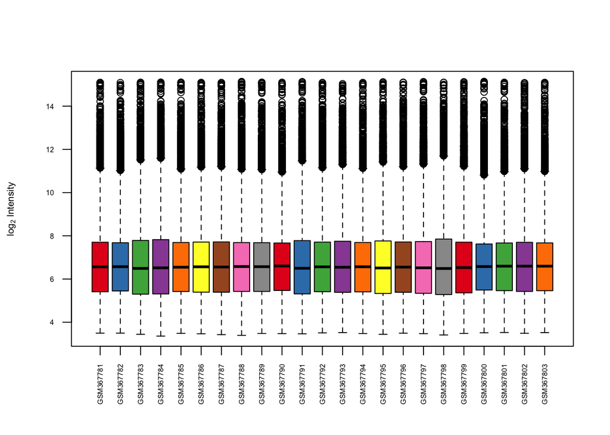

```r
# create box plots to verify pre-processing
boxplot(exprs_data, col = brewer.pal(9, 'Set1'),
        cex.axis = 0.5, cex.lab = 0.65, las=2,
        ylab = TeX('$log_{2}$ Intensity'))
```

```r
# check for NA values
cat('There are', sum(is.na(exprs_data)), 'NA values')
```

```
## There are 0 NA values
```

```r
# remove duplicate gene names
exprs_data_clean = exprs_data[!duplicated(rownames(exprs_data)),]

## Filtering
# summarize average gene expression values
avg <- rowMeans(exprs_data_clean)
summary(avg)
```

```
##    Min. 1st Qu.  Median    Mean 3rd Qu.    Max.
##   3.550   5.409   6.568   6.681   7.698  15.098
```

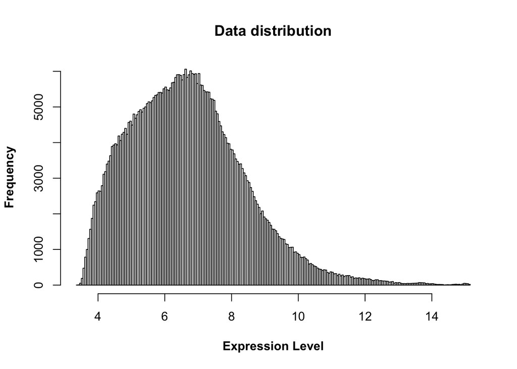

```
## Keep probes with at least 1 sample(s) with an expression level higher than FALSE
```

```r
# view distribution to determine whether or not filtering is needed
EMA::expFilter(exprs_data_clean, threshold = FALSE, graph = TRUE)
```

```r
# # filter and discard probesets with a maximum log2 expression value below x, p=0.01
# PUBHI.f = expFilter(PHBI.exprs, threshold=x)
```

If the expression data have been both normalized and log transformed the samples will have similar $log_{2}$ intensity distributions (first plot). If the data has been filtered the distribution should appear somewhat ‘normal’ (second plot).

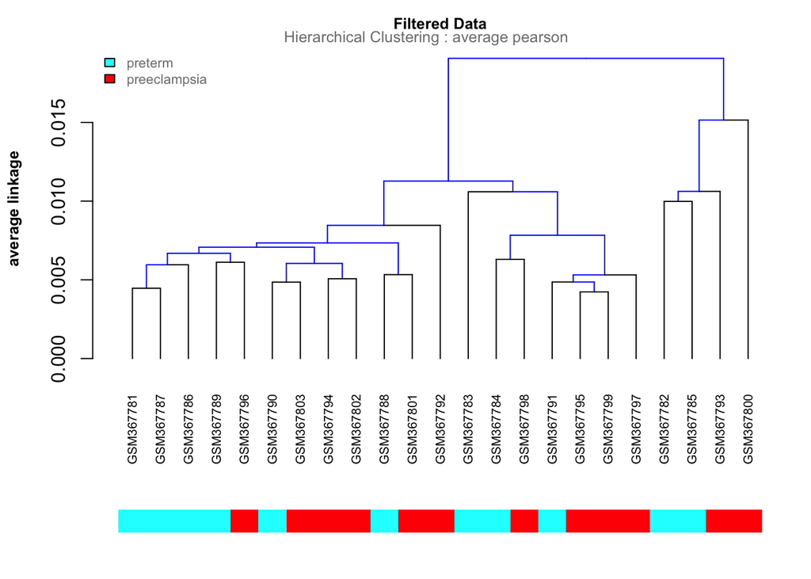

```r
# cluster expression data by sample
sample = EMA::clustering(data = exprs_data_clean, metric = 'pearson', method = 'average')
EMA::clustering.plot(tree = sample, lab = groups, title = 'Filtered Data', scale='row', legend.pos = 'topleft')
```

```r
## Principle Components Analysis
# segment variation into different components
acp = EMA::runPCA(t(exprs_data_clean), scale = FALSE, lab.sample = groups, plotSample = FALSE, plotInertia = FALSE)
names(acp$eig) = c('eigen', '%var', 'cumm %var')

knitr::kable(head(acp$eig))
```

|  | eigen | %var | cumm %var |
| --- | --- | --- | --- |
| comp 1 | 417.52058 | 25.508241 | 25.50824 |
| comp 2 | 386.58619 | 23.618317 | 49.12656 |
| comp 3 | 160.86811 | 9.828168 | 58.95473 |
| comp 4 | 83.77831 | 5.118400 | 64.07313 |
| comp 5 | 68.05461 | 4.157767 | 68.23089 |
| comp 6 | 62.25019 | 3.803149 | 72.03404 |

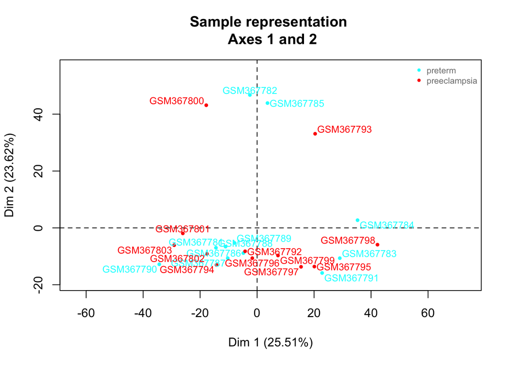

```r
# EMA::plotInertia(acp)

# view variation between samples
EMA::plotSample(acp, axes = c(1, 2), lab = groups)
```

```r
# save cleaned expression data
exp = as.data.frame(cbind(rownames(exprs_data_clean), exprs_data_clean))
names(exp) = c('probe', colnames(exprs_data_clean))
write.table(exp, file = paste('GEO_Data/', id, '_clean_exp_data.txt', sep = ' '),
            sep = '\t',
            row.names = FALSE,
            col.names = TRUE,
            quote = FALSE)
```

## Differential Expression Analysis

Differential expression analysis was performed on the pre-processed microarray data using limma ( [microarray](http://bioconductor.org/packages/release/bioc/vignettes/limma/inst/doc/usersguide.pdf)).

```r
## Run Differential Expression Analysis
# create design matrix
design <- stats::model.matrix(~ groups + 0, data.frame(exprs_data_clean))
colnames(design) <- gsub('groups', '', colnames(design))
design
```

```
##    preeclampsia preterm
## 1             0       1
## 2             0       1
## 3             0       1
## 4             0       1
## 5             0       1
## 6             0       1
## 7             0       1
## 8             0       1
## 9             0       1
## 10            0       1
## 11            0       1
## 12            1       0
## 13            1       0
## 14            1       0
## 15            1       0
## 16            1       0
## 17            1       0
## 18            1       0
## 19            1       0
## 20            1       0
## 21            1       0
## 22            1       0
## 23            1       0
## attr(,"assign")
## [1] 1 1
## attr(,"contrasts")
## attr(,"contrasts")$groups
## [1] "contr.treatment"
```

```r
# create constrast
contr.matrix <- limma::makeContrasts(
   PEvsPT = preeclampsia-preterm,
   levels = colnames(design))
contr.matrix
```

```
##               Contrasts
## Levels         PEvsPT
##   preeclampsia      1
##   preterm          -1
```

```r
# fit model
fit <- limma::lmFit(data.frame(exprs_data_clean), design)
fit <- limma::contrasts.fit(fit, contrasts=contr.matrix)
efit <- limma::eBayes(fit)

# get results adjusting for multiple testing using FDR
results = limma::topTable(efit, coef=1, adjust='fdr', lfc=0, number=Inf)
knitr::kable(head(results, n = 10))
```

|  | logFC | AveExpr | t | P.Value | adj.P.Val | B |
| --- | --- | --- | --- | --- | --- | --- |
| 203140_at | 1.3830903 | 8.701317 | 7.898771 | 0.0e+00 | 0.0007187 | 7.777106 |
| 205629_s_at | 2.6747973 | 10.253366 | 6.802124 | 4.0e-07 | 0.0046884 | 5.772355 |
| 210511_s_at | 1.9633927 | 11.272463 | 6.287382 | 1.5e-06 | 0.0075284 | 4.761359 |
| 207092_at | 3.5606629 | 8.620377 | 6.243416 | 1.7e-06 | 0.0075284 | 4.673064 |
| 205829_at | -0.8801543 | 11.055942 | -6.233580 | 1.7e-06 | 0.0075284 | 4.653271 |
| 215812_s_at | 0.7167603 | 8.335988 | 5.902105 | 3.9e-06 | 0.0113839 | 3.977905 |
| 210141_s_at | 1.3775180 | 8.654491 | 5.896522 | 3.9e-06 | 0.0113839 | 3.966397 |
| 222033_s_at | 1.5237636 | 8.682469 | 5.869942 | 4.2e-06 | 0.0113839 | 3.911545 |
| 219542_at | 0.5498589 | 7.731062 | 5.812721 | 4.9e-06 | 0.0113839 | 3.793134 |
| 221665_s_at | 0.8404635 | 8.996666 | 5.790652 | 5.1e-06 | 0.0113839 | 3.747349 |

```r
# add gene information to efit
efit$genes <- GSE_genes

# print number of up and down regulated genes between the samples
top_dec_test <- decideTests(efit)
knitr::kable(summary(top_dec_test))
```

|  | PEvsPT |
| --- | --- |
| -1 | 1 |
| 0 | 22083 |
| 1 | 31 |

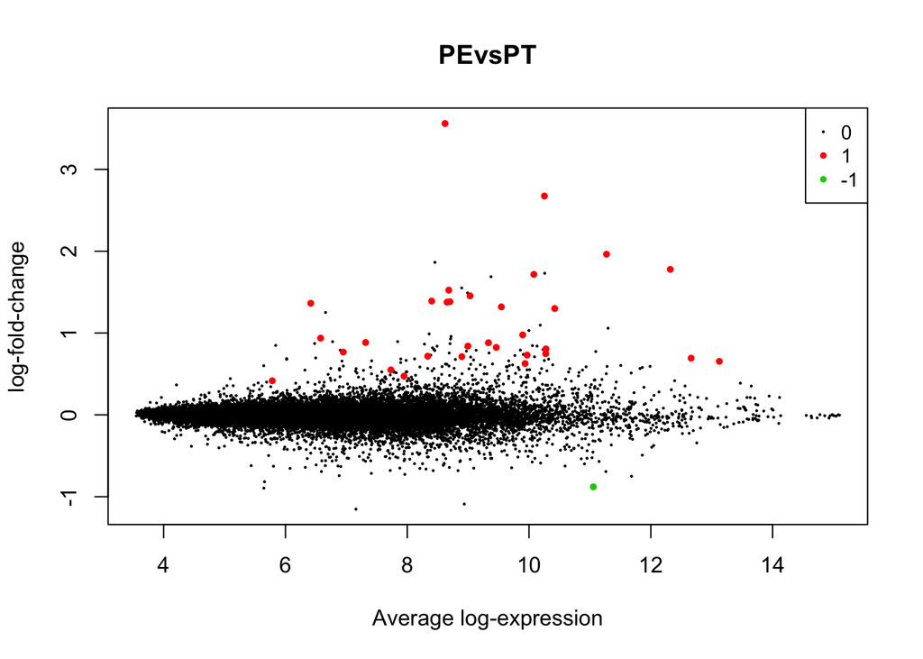

```r
# print diagram of up and down regulated genes
plotMD(efit, column=1, status=top_dec_test[,1], main=colnames(efit)[1], cex = 0.7)
```

```r
## Process Results
limma::write.fit(efit, top_dec_test, adjust='fdr', file=paste('DE_Results/', id ,'_DEgenes.txt', sep = ' '))
```

The plot shows the up (red) and down (green) regulated differentially expressed genes between the samples.

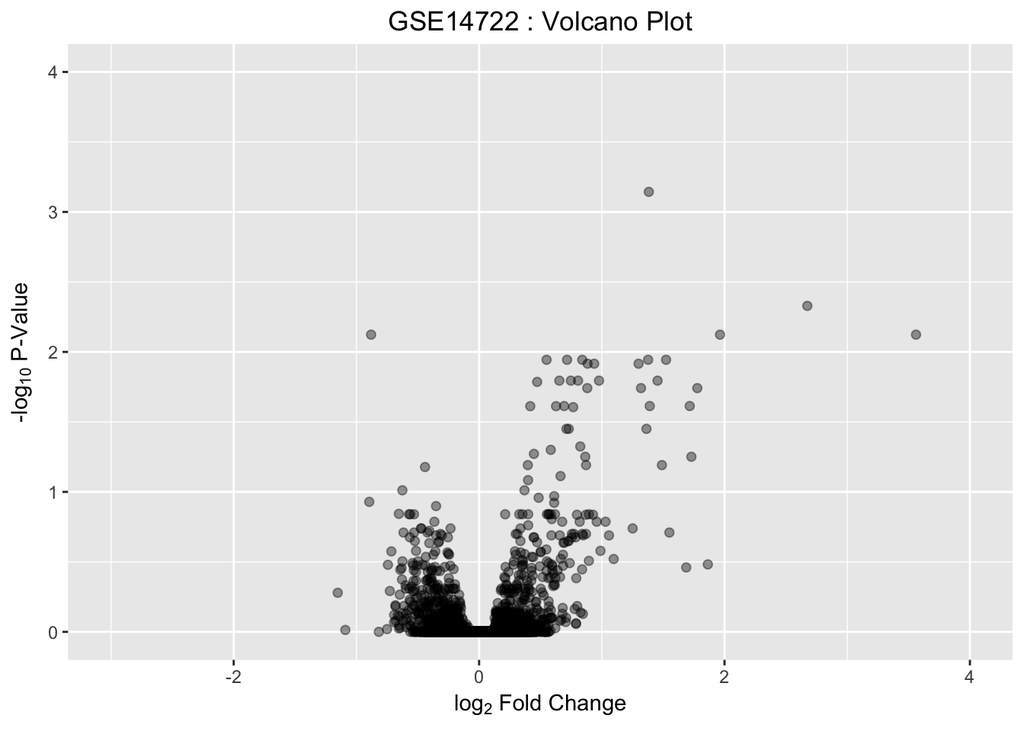

```r
## Visualize results
# volcano plot
ggplot2::theme_update(plot.title = element_text(hjust = 0.5))
ggplot2::ggplot(data = results, aes(x = results$logFC, y = -log10(results$adj.P.Val)), colour = none) +
       geom_point(alpha = 0.4, size = 1.75) +
       labs(title = paste(id, ': Volcano Plot', sep = ' ')) +
       xlim(c(ceiling(-max(results$logFC)), ceiling(max(results$logFC)))) +
       ylim(c(0, ceiling(max(-log10(results$adj.P.Val))))) +
       ylab(TeX('$-log_{10}$ P-Value')) +
       xlab(TeX('$log_{2}$ Fold Change'))
```

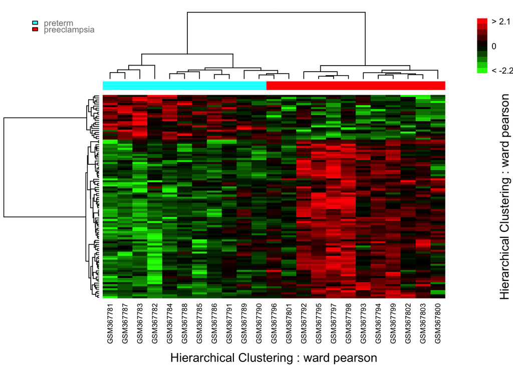

```r
# heatmap - top 100 genes
mvgenes = as.character(rownames(results)[1:100])
c.sample <- EMA::clustering(data = exprs_data_clean[mvgenes, ], metric = 'pearson', method = 'ward')
c.gene <- EMA::clustering(data = t(exprs_data_clean[mvgenes, ]), metric = 'pearson', method = 'ward')
EMA::clustering.plot(tree = c.sample, tree.sup = c.gene, data = exprs_data_clean[mvgenes,
    ], names.sup = FALSE, lab = groups, trim.heatmap = 0.99, scale = 'row')
```

## Accessing GEO Data

### RNA-Seq Data

RNA-Seq data is a bit more complicated to analyze then the microarray data. To get expression data, the count data data needs to be downloaded and fully processed. The [Bioconductor RNA-Seq Workflow](https://www.bioconductor.org/help/workflows/RNAseq123/) developed by the [Smyth Lab](https://www.wehi.edu.au/people/gordon-smyth) was used.

```r
## Download Data
id <- 'GSE63310'
url <- paste('https://www.ncbi.nlm.nih.gov/geo/download/?acc=', id, '&format=file', sep = '')
utils::download.file(url, destfile=paste('Raw_GEO_Data/', id, '_RAW.tar', sep=''), mode='wb')

# unzip data to directory, where directory has same name as id
utils::untar(paste('Raw_GEO_Data/', id, '_RAW.tar', sep=''), exdir = paste('Raw_GEO_Data/',
                                                                           id, sep=''))
# list all files in directory
files <- list.files(path = paste('Raw_GEO_Data/', id, sep=''), full.names=TRUE)

# check to see if data has already been extracteds before extracting
if(!any(grepl('*.txt$', files))){
  # unzip sub-directories
  sapply(files, function(i) R.utils::gunzip(i, overwrite = TRUE))

} else {
  # delete them
  lapply(files, function(x) file.remove(x,
  pattern = "*.txt$",
  full.names = TRUE))

  # download data
  utils::download.file(url, destfile=paste('Raw_GEO_Data/', id, '_RAW.tar', sep=''), mode='wb')

  # unzip data to directory, where directory has same name as id
  utils::untar(paste('Raw_GEO_Data/', id, '_RAW.tar', sep=''), exdir = paste('Raw_GEO_Data/', id, sep=''))

  # list all files in   directory
  files <- list.files(path = paste('Raw_GEO_Data/', id, sep=''), full.names=TRUE)

  # then extract new data
  sapply(files, function(i) R.utils::gunzip(i, overwrite = TRUE))
}

# delete zipped file
file.remove(paste('Raw_GEO_Data/', id, '_RAW.tar', sep=''))

# download series information on samples
gse <- GEOquery::getGEO('GSE63310', GSEMatrix = TRUE)

# get group info - remove samples we are not including (i.e., 3 and 9)
group_info = as.character(gse[[1]]@phenoData@data$title)[-c(3, 9)]

# get batch info
batch_info = as.character(gse[[1]]@phenoData@data$characteristics_ch1.6)[-c(3, 9)]
```

```r
# specify GEO accession id
id <- 'GSE63310'

# read in text files and create single matrix of counts
unzipped_files <- list.files(path = paste('Raw_GEO_Data/', id, sep=''), full.names=TRUE)[-c(3, 9)]

# review file
head(read.table(unzipped_files[1]))
```

```
##          V1         V2    V3
## 1  EntrezID GeneLength Count
## 2    497097       3634     1
## 3 100503874       3259     0
## 4 100038431       1634     0
## 5     19888       9747     0
## 6     20671       3130     1
```

```r
# crete DGE object
DGE <- edgeR::readDGE(unzipped_files, columns=c(1,3))

# remove GEO sample IDs from column names
samplenames <- substring(colnames(DGE), nchar(paste('Raw_GEO_Data/', id, sep='')) + 13, nchar(colnames(DGE)))
colnames(DGE) <- samplenames
samplenames
```

```
## [1] "10_6_5_11" "9_6_5_11"  "purep53"   "JMS8-2"    "JMS8-3"    "JMS8-4"
## [7] "JMS8-5"    "JMS9-P7c"  "JMS9-P8c"
```

```r
# create groups
group = as.factor(as.character(lapply(samplenames, function(x) sub(',.*', '', group_info[grepl(x, group_info)]))))
group
```

```
## [1] LP    ML    Basal Basal ML    LP    Basal ML    LP
## Levels: Basal LP ML
```

```r
# DGEList-object contains a samples data frame that stores both cell type (or group) and batch (sequencing lane) informations
DGE$samples$group <- group
lane <- as.factor(as.character(lapply(batch_info, function(x) sub(': ', '', x))))
DGE$samples$lane <- lane
head(DGE$samples)
```

```
##                                                    files group lib.size
## 10_6_5_11 Raw_GEO_Data/GSE63310/GSM1545535_10_6_5_11.txt    LP 32863052
## 9_6_5_11   Raw_GEO_Data/GSE63310/GSM1545536_9_6_5_11.txt    ML 35335491
## purep53     Raw_GEO_Data/GSE63310/GSM1545538_purep53.txt Basal 57160817
## JMS8-2       Raw_GEO_Data/GSE63310/GSM1545539_JMS8-2.txt Basal 51368625
## JMS8-3       Raw_GEO_Data/GSE63310/GSM1545540_JMS8-3.txt    ML 75795034
## JMS8-4       Raw_GEO_Data/GSE63310/GSM1545541_JMS8-4.txt    LP 60517657
##           norm.factors   lane
## 10_6_5_11            1 batch1
## 9_6_5_11             1 batch1
## purep53              1 batch1
## JMS8-2               1 batch2
## JMS8-3               1 batch2
## JMS8-4               1 batch2
```

```r
## Get Gene Annotations ##
# get Entrez gene ids from DGEList-object
geneid <- rownames(DGE)
head(geneid)
```

```
## [1] "497097"    "100503874" "100038431" "19888"     "20671"     "27395"
```

```r
# get additional gene information
genes <- AnnotationDbi::select(Mus.musculus, keys=geneid, columns=c('SYMBOL'),
                keytype='ENTREZID')
```

```r
# # aggregate 1:many mappings into single list
# entrez = aggregate(ENTREZID ~ ENSEMBL, data = genes, paste, collapse = ' /// ')
# symbol = aggregate(SYMBOL ~ ENSEMBL, data = genes, paste, collapse = ' /// ')
#
# # merge lists together
# gene_merge = merge(entrez, symbol, by = 'ENSEMBL', all = TRUE)

# add this information to DGEList-object
DGE$genes <- genes
```

## Pre-Processing and Quality Control

Prior to determining which genes are differentially expressed, the expression data processing is processed. The pre-processing pipeline includes: log transformation, filtering of lowly expressed genes, normalization, and clustering by sample and lane.

```r
## Log-Transformation
#convert raw count to CPM and log-CPM values
cpm <- edgeR::cpm(DGE)
lcpm <- edgeR::cpm(DGE, log=TRUE)

## Filter Lowly Expressed Genes
# get count of genes with count of 0
table(rowSums(DGE$counts==0)==length(samplenames))
```

```
##
## FALSE  TRUE
## 22026  5153
```

```r
dim(DGE)
```

```
## [1] 27179     9
```

```r
# get counts by sample
knitr::kable(data.table(samplenames, counts = as.numeric(lapply(colSums(DGE$counts), function(x) x/1000000))))
```

| samplenames | counts |
| --- | --- |
| 10_6_5_11 | 32.86305 |
| 9_6_5_11 | 35.33549 |
| purep53 | 57.16082 |
| JMS8-2 | 51.36863 |
| JMS8-3 | 75.79503 |
| JMS8-4 | 60.51766 |
| JMS8-5 | 55.08632 |
| JMS9-P7c | 21.31107 |
| JMS9-P8c | 19.95884 |

```r
# remove genes using cpm > 1 as threshold, where a gene must be expressed in at least 3 samples
keep.exprs <- rowSums(cpm>1) >= 3
DGE <- DGE[keep.exprs,, keep.lib.sizes=FALSE]
dim(DGE)
```

```
## [1] 14165     9
```

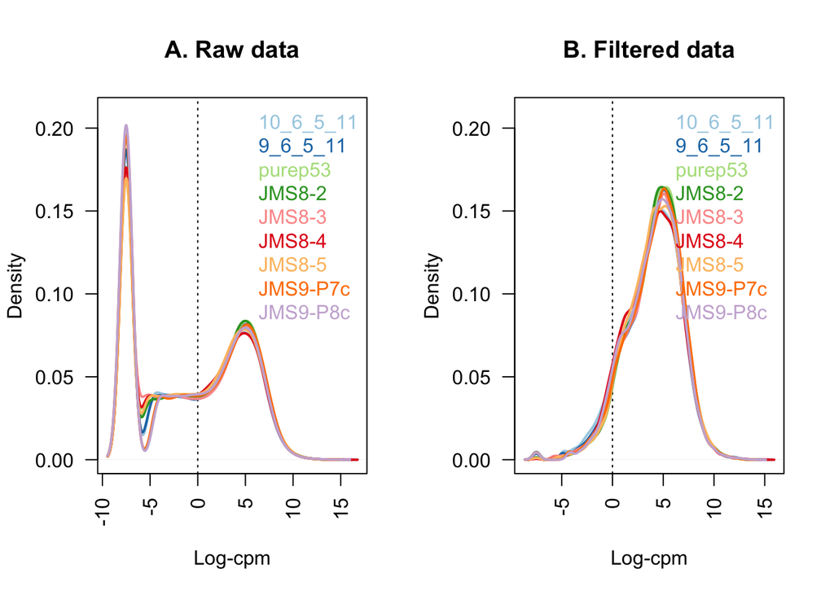

```r
# visualize density plots before and after filtering
nsamples <- ncol(DGE)
col <- brewer.pal(nsamples, 'Paired')
par(mfrow=c(1,2))
plot(density(lcpm[,1]), col=col[1], lwd=2, ylim=c(0,0.21), las=2,
     main='', xlab='')
title(main='A. Raw data', xlab='Log-cpm')
abline(v=0, lty=3)
for (i in 2:nsamples){
 den <- density(lcpm[,i])
 lines(den$x, den$y, col=col[i], lwd=2)
}
legend('topright', samplenames, text.col=col, bty='n')
lcpm <- cpm(DGE, log=TRUE)
plot(density(lcpm[,1]), col=col[1], lwd=2, ylim=c(0,0.21), las=2,
     main='', xlab='')
title(main='B. Filtered data', xlab='Log-cpm')
abline(v=0, lty=3)
for (i in 2:nsamples){
   den <- density(lcpm[,i])
   lines(den$x, den$y, col=col[i], lwd=2)
}
legend('topright', samplenames, text.col=col, bty='n')
```

```r
par(mfrow=c(1,1))
#The density of log-CPM values for raw pre-filtered data (A) and post-filtered data (B) are shown for each sample. Dotted vertical lines mark the log-CPM of zero threshold (equivalent to a CPM value of 1) used in the filtering step.
```

The density of log-CPM values for raw pre-filtered data (A) and post-filtered data (B) are shown for each sample. Dotted vertical lines mark the log-CPM of zero threshold (equivalent to a CPM value of 1) used in the filtering step.

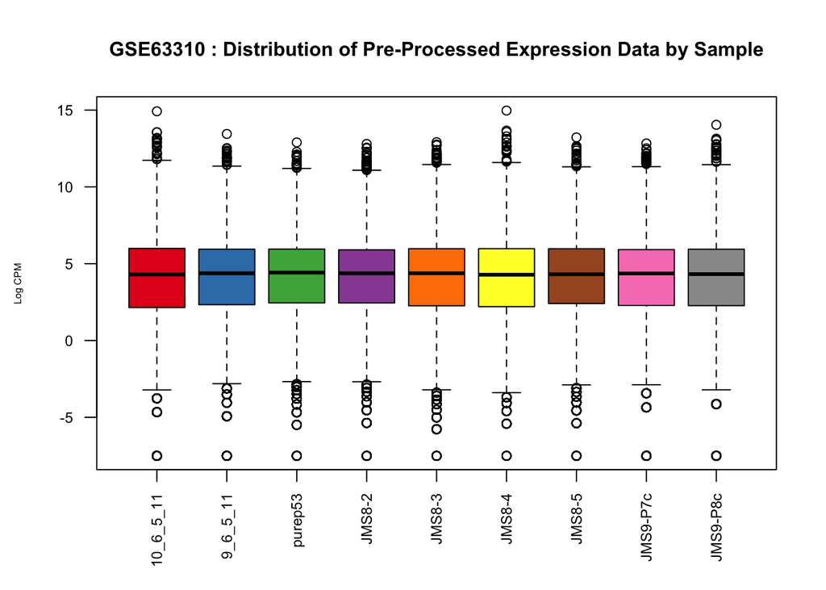

```r
## Normalize Expression Distributions
#trimmed mean of M-values (TMM) (Robinson and Oshlack 2010) is performed using the calcNormFactors function in edgeR
DGE <- calcNormFactors(DGE, method = 'TMM')

# box plots to verify pre-processing
boxplot(cpm(DGE, log = TRUE), col = brewer.pal(9, 'Set1'),
        cex.axis = 0.75, cex.lab = 0.5, las=2, cex.main = 1.0,
        main = paste(id, ': Distribution of Pre-Processed Expression Data by Sample', sep = ' '),
        ylab = 'Log CPM')
```

The samples should have similar $log_{2}$ intensity distributions.

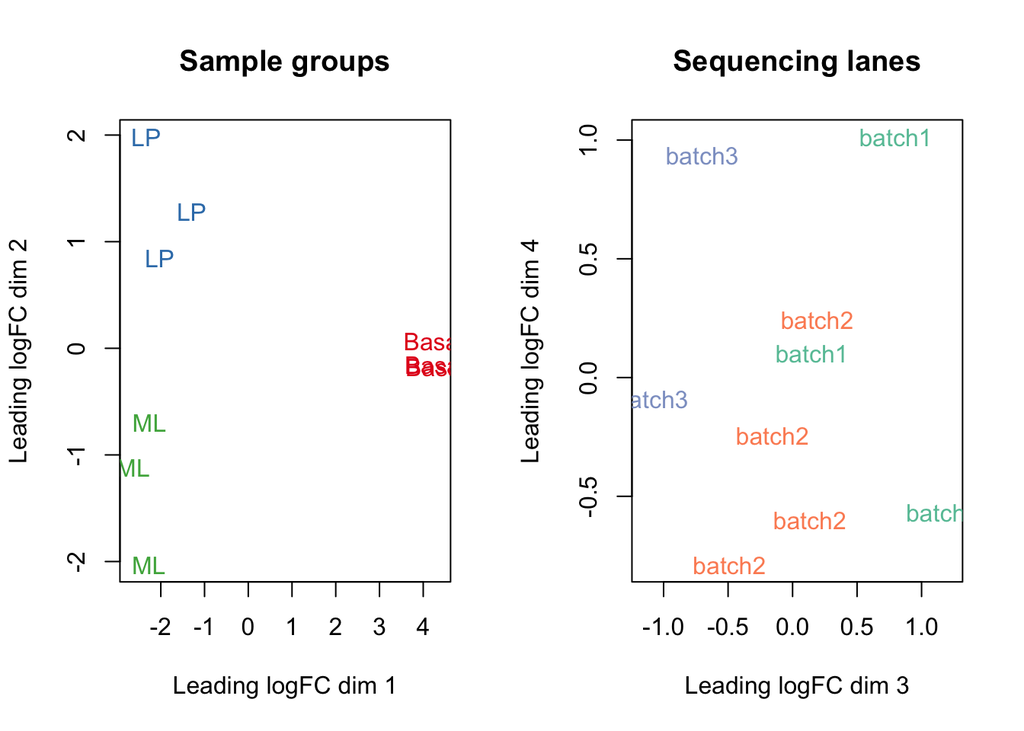

```r
## Clustering by Sample and Sequencing Lane
# SAMPLES
par(mfrow=c(1,2))
col.group <- group
levels(col.group) <-  brewer.pal(nlevels(col.group), 'Set1')
col.group <- as.character(col.group)
plotMDS(cpm(DGE, log = TRUE), labels=group, col= col.group)
title(main='Sample groups')

# SEQUENCING LANES
col.lane <- lane
levels(col.lane) <-  brewer.pal(nlevels(col.lane), 'Set2')
col.lane <- as.character(col.lane)
plotMDS(cpm(DGE, log = TRUE), labels=lane, col=col.lane, dim=c(3,4))
title(main='Sequencing lanes')
```

```r
par(mfrow=c(1,1))
```

Samples appear to cluster by their grouping providing evidence that the set of genes may be differentially expressed.

## Differential Expression Analysis

Differential expression analysis was performed on RNA-seq data using limma ([RNA-seq](https://www.bioconductor.org/help/workflows/RNAseq123/)). As mentioned above, once RNA-seq has been processed with voom a similar differential expression analysis pipeline via limma used for microarray data can also be used with RNA-seq data.

```r
# set-up design matrix
design <- stats::model.matrix(~0+group+lane)
colnames(design) <- gsub('group', '', colnames(design))
design
```

```
##   Basal LP ML lanebatch2 lanebatch3
## 1     0  1  0          0          0
## 2     0  0  1          0          0
## 3     1  0  0          0          0
## 4     1  0  0          1          0
## 5     0  0  1          1          0
## 6     0  1  0          1          0
## 7     1  0  0          1          0
## 8     0  0  1          0          1
## 9     0  1  0          0          1
## attr(,"assign")
## [1] 1 1 1 2 2
## attr(,"contrasts")
## attr(,"contrasts")$group
## [1] "contr.treatment"
##
## attr(,"contrasts")$lane
## [1] "contr.treatment"
```

```r
# set-up contrasts - want ocntrol group to be negative
contr.matrix <- makeContrasts(
   BasalvsLP = Basal-LP,
   BasalvsML = Basal-ML,
   LPvsML = LP-ML,
   levels = colnames(design))
contr.matrix
```

```
##             Contrasts
## Levels       BasalvsLP BasalvsML LPvsML
##   Basal              1         1      0
##   LP                -1         0      1
##   ML                 0        -1     -1
##   lanebatch2         0         0      0
##   lanebatch3         0         0      0
```

```r
## remove heteroscedascity from count data - voom
par(mfrow=c(1,2))
v <- voom(DGE, design, plot=TRUE)
v
```

```
## An object of class "EList"
## $genes
##    ENTREZID SYMBOL
## 1    497097   Xkr4
## 6     27395 Mrpl15
## 7     18777 Lypla1
## 9     21399  Tcea1
## 10    58175  Rgs20
## 14160 more rows ...
##
## $targets
##                                                    files group lib.size
## 10_6_5_11 Raw_GEO_Data/GSE63310/GSM1545535_10_6_5_11.txt    LP 29409426
## 9_6_5_11   Raw_GEO_Data/GSE63310/GSM1545536_9_6_5_11.txt    ML 36528591
## purep53     Raw_GEO_Data/GSE63310/GSM1545538_purep53.txt Basal 59598629
## JMS8-2       Raw_GEO_Data/GSE63310/GSM1545539_JMS8-2.txt Basal 53382070
## JMS8-3       Raw_GEO_Data/GSE63310/GSM1545540_JMS8-3.txt    ML 78175314
## JMS8-4       Raw_GEO_Data/GSE63310/GSM1545541_JMS8-4.txt    LP 55762781
## JMS8-5       Raw_GEO_Data/GSE63310/GSM1545542_JMS8-5.txt Basal 54115150
## JMS9-P7c   Raw_GEO_Data/GSE63310/GSM1545544_JMS9-P7c.txt    ML 23043111
## JMS9-P8c   Raw_GEO_Data/GSE63310/GSM1545545_JMS9-P8c.txt    LP 19525423
##           norm.factors   lane
## 10_6_5_11    0.8957309 batch1
## 9_6_5_11     1.0349196 batch1
## purep53      1.0439552 batch1
## JMS8-2       1.0405040 batch2
## JMS8-3       1.0323599 batch2
## JMS8-4       0.9223424 batch2
## JMS8-5       0.9836603 batch2
## JMS9-P7c     1.0827381 batch3
## JMS9-P8c     0.9792607 batch3
##
## $E
##         Samples
## Tags     10_6_5_11  9_6_5_11   purep53    JMS8-2    JMS8-3    JMS8-4
##   497097 -4.293244 -3.869026  2.522753  3.302006 -4.481286 -3.993876
##   27395   3.875010  4.400568  4.521172  4.570624  4.322845  3.786547
##   18777   4.707695  5.559334  5.400569  5.171235  5.627798  5.081794
##   21399   4.784462  4.741999  5.374548  5.130925  4.848030  4.944024
##   58175   3.943567  3.294875 -1.767924 -1.880302  2.993289  3.357379
```

[output cut: 28 more lines]

```
## 3     1  0  0          0          0
## 4     1  0  0          1          0
## 5     0  0  1          1          0
## 6     0  1  0          1          0
## 7     1  0  0          1          0
## 8     0  0  1          0          1
## 9     0  1  0          0          1
## attr(,"assign")
## [1] 1 1 1 2 2
## attr(,"contrasts")
## attr(,"contrasts")$group
## [1] "contr.treatment"
##
## attr(,"contrasts")$lane
## [1] "contr.treatment"
```

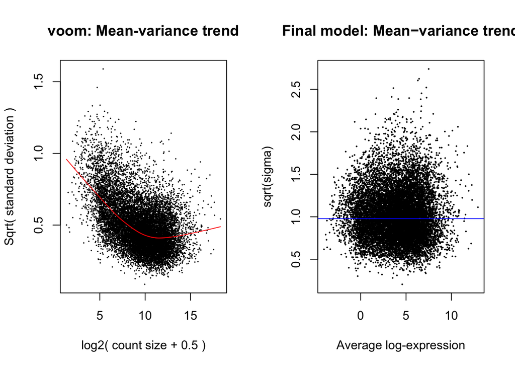

```r
## fit model
fit <- limma::lmFit(v, design)
fit <- limma::contrasts.fit(fit, contrasts=contr.matrix)
efit <- limma::eBayes(fit)
limma::plotSA(efit, main='Final model: Mean−variance trend')
```

```r
par(mfrow=c(1,1))
```

```r
# print number of up and down regulated genes between the samples
top_dec_test <- decideTests(efit)
knitr::kable(summary(top_dec_test))
```

|  | BasalvsLP | BasalvsML | LPvsML |
| --- | --- | --- | --- |
| -1 | 4127 | 4338 | 2895 |
| 0 | 5740 | 5655 | 8825 |
| 1 | 4298 | 4172 | 2445 |

```r
# print number of up and down regulated genes
summary(decideTests(efit))
```

```
##    BasalvsLP BasalvsML LPvsML
## -1      4127      4338   2895
## 0       5740      5655   8825
## 1       4298      4172   2445
```

```r
# re-run model with a cut-off of a log-fold change of 1
tfit <- treat(fit, lfc=1)
top_dec_test <- decideTests(tfit)
summary(top_dec_test)
```

```
##    BasalvsLP BasalvsML LPvsML
## -1      1417      1512    203
## 0      11030     10895  13780
## 1       1718      1758    182
```

```r
## Process Results
limma::write.fit(tfit, top_dec_test, adjust='fdr', file=paste('DE_Results/', id ,'_DEgenes.txt', sep = ' '))
```

```r
# view list of genes significantly expressed across all sample comparisons
de.common <- which(top_dec_test[,1]!=0 & top_dec_test[,2]!=0)
length(de.common)
```

```
## [1] 2409
```

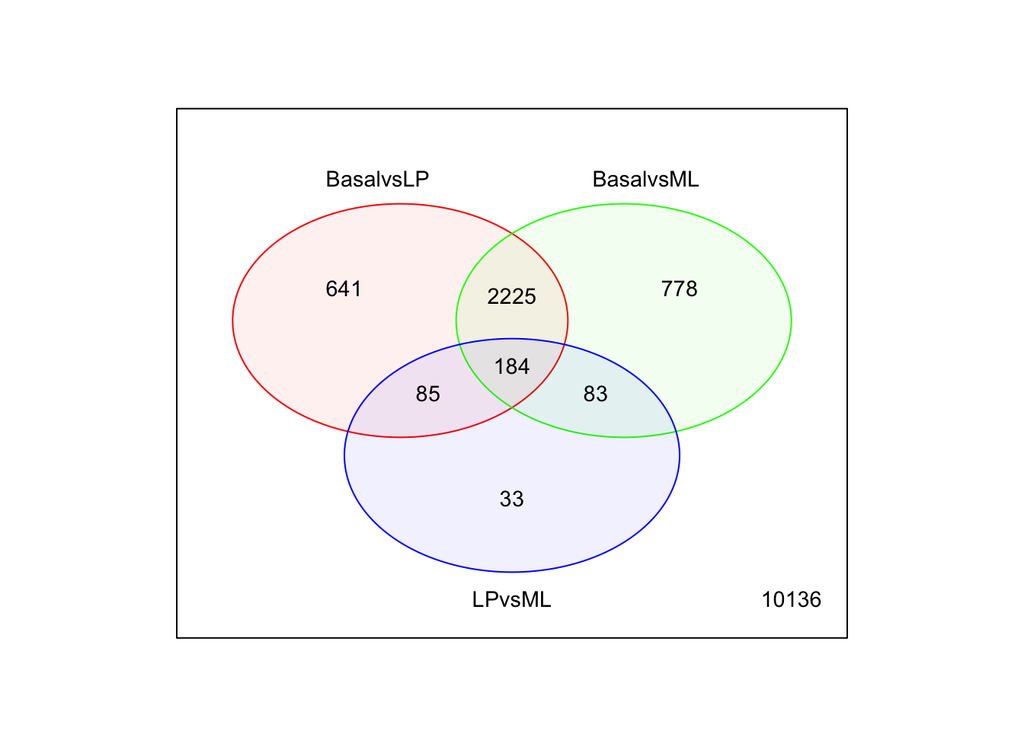

```r
# visualize in venn diagram
limma::vennDiagram(top_dec_test, circle.col=rainbow(n=3), cex = 0.9)
```

[figure not shown]

```r
# MD plot
limma::plotMD(tfit, column=1, status=top_dec_test[,1], main=colnames(tfit)[1],
       xlim=c(-8,13), cex.axis = 0.5, cex.lab = 0.5, cex.main=0.75)
```

[figure not shown]

```r
limma::plotMD(tfit, column=1, status=top_dec_test[,2], main=colnames(tfit)[2],
       xlim=c(-8,13))
```

[figure not shown]

```r
limma::plotMD(tfit, column=1, status=top_dec_test[,3], main=colnames(tfit)[3],
       xlim=c(-8,13))
```

```r
# get top DEG by group comparisons
basal.vs.lp <- topTreat(tfit, coef=1, n=Inf)
head(basal.vs.lp)
```

```
##        ENTREZID SYMBOL     logFC  AveExpr         t      P.Value
## 12759     12759    Clu -5.442877 8.857907 -33.44429 3.990899e-10
## 53624     53624  Cldn7 -5.514605 6.296762 -32.94533 4.503694e-10
## 242505   242505  Rasef -5.921741 5.119585 -31.77625 6.063249e-10
## 67451     67451   Pkp2 -5.724823 4.420495 -30.65370 8.010456e-10
## 228543   228543   Rhov -6.253427 5.486640 -29.46244 1.112729e-09
## 70350     70350  Basp1 -6.073297 5.248349 -28.64890 1.380545e-09
##           adj.P.Val
## 12759  2.703871e-06
## 53624  2.703871e-06
## 242505 2.703871e-06
## 67451  2.703871e-06
## 228543 2.703871e-06
## 70350  2.703871e-06
```

```r
basal.vs.ml <- topTreat(tfit, coef=2, n=Inf)
head(basal.vs.ml)
```

```
##        ENTREZID  SYMBOL     logFC  AveExpr         t      P.Value
## 242505   242505   Rasef -6.510470 5.119585 -35.49093 2.573575e-10
## 53624     53624   Cldn7 -5.469160 6.296762 -32.52520 4.978446e-10
## 12521     12521    Cd82 -4.667737 7.070963 -31.82187 5.796191e-10
## 71740     71740 Nectin4 -5.556046 5.166292 -31.29987 6.760578e-10
## 20661     20661   Sort1 -4.908119 6.705784 -31.23083 6.761331e-10
## 15375     15375   Foxa1 -5.753884 5.625064 -28.34612 1.487280e-09
##           adj.P.Val
## 242505 1.915485e-06
## 53624  1.915485e-06
## 12521  1.915485e-06
## 71740  1.915485e-06
## 20661  1.915485e-06
## 15375  2.281914e-06
```

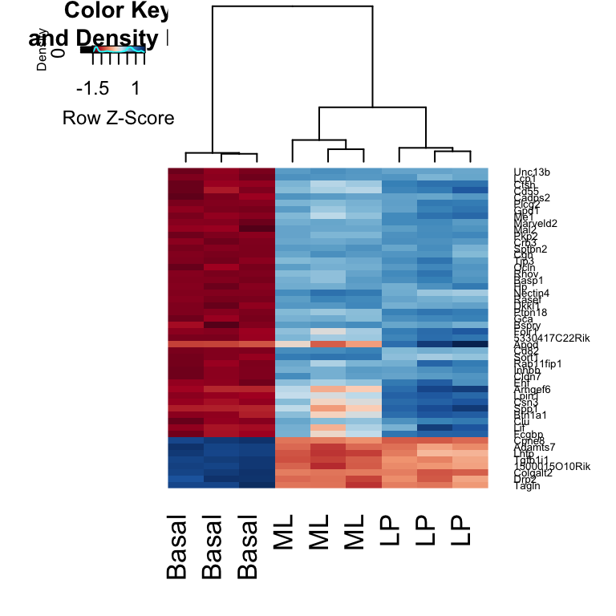

```r
# heat map
basal.vs.lp.topgenes <- basal.vs.lp$ENTREZID[1:50]
i <- which(v$genes$ENTREZID %in% basal.vs.lp.topgenes)
cols <- colorRampPalette(brewer.pal(10, 'RdBu'))(256)
gplots::heatmap.2(v$E[i,], scale='row',
   labRow=v$genes$SYMBOL[i], labCol=group, col = cols,
   trace='none', density.info='density', dendrogram='column', cexRow = 0.5)
```

## GEO Metadata Retrieval

The GEO Metadata Database is used to retrieve important metadata about GEO data sets used in the current analysis. Specifically, the GES Accession identifier, study type (i.e., expression profiling by array, Expression profiling by high throughput sequencing), PubMed identifier, and the original date that the data was submitted to GEO.

```r
## Connect to database
con <- DBI::dbConnect(SQLite(),'GEO_Database/GEOmetadb.sqlite')

# query a table
metadata <- DBI::dbGetQuery(con,'SELECT gse, pubmed_id, title, submission_date, type, overall_design
                      FROM gse
                      WHERE gse IN ("GSE14722", "GSE63310")')

# print results
knitr::kable(metadata)
```

| gse | pubmed_id | title | submission_date | type | overall_design |
| --- | --- | --- | --- | --- | --- |
| GSE14722 | 18818296 | Severe Preeclampsia-Related Changes in Gene Expression at the Maternal-Fetal Interface Include Siglec-6 and Pappalysin-2 | 2009-02-05 | Expression profiling by array | Basal plate biopsies of preterm labor (24-36 weeks; n=11) and preterm severe preeclampsia (24-36 weeeks; n=12) were isolated and the global gene expression profiles determined using Affymetrix Human G… |
| GSE63310 | NA | Transcriptome profiling of purified mouse mammary stem, progenitor and mature cell populations | 2014-11-14 | Expression profiling by high throughput sequencing | Total RNA was extracted and purified from sorted luminal or basal populations from the mammary glands of female virgin 8- to 10-week-old FVB/N mice (3 independent samples for population), MaSC/Basal c… |

```r
# write metadata to csv
write.csv(metadata,
            'GEO_Data/GES_Metadata.csv',
            row.names = FALSE,
            quote = FALSE)

# close db connection
DBI::dbDisconnect(con)
```